# AIFFD Chapter 13 - Fish Population Bioassessment

### 13.5.5 Regression Analysis of $k$ Values

In the box, the author first demonstrates plotting the $k_{i}$ and $K$ values against cohort year to visually estimate which $k_{i}$ most closely tracked the trend in $K$ and, thus, contributed 11most" to $K$. The author used a plot with two y-axes for this procedure. I’m not a fan of graphs with two y-axes so I will make side-by-side plots with the $k_{i}$ versus cohort year on one plot and $K$ versus cohort year on the other. Before constructing these plots, the vector of $K$ values must be created as the sum of the $k_{i}$ values for a given cohort year. In addition, it will be easier to work with the `k` matrix if it is transposed (using `t()`) so that a set of $k_{i}$ values is in a column. Finally, before plotting, the cohort year numbers are extracted and saved to an object. The plot of $k_{i}$ values against cohort year is then accomplished with `matplot()` which takes the x-axis values as the first argument, a matrix of y-axis values as the second argument, and then the usual optional control arguments. The plot of $K$ against cohort year is simply accomplished with the familiar `plot()`.

```r
> ( K <- apply(k,2,sum) )
```

```
    1949     1950     1951     1952     1953     1954     1955     1956
3.929419 4.000000 3.665112 3.292597 3.371611 3.602060 3.331844 3.445864
    1957     1958     1959
3.687975 3.462974 3.723412
```

```r
> ( kt <- t(k) )
```

```
           k0        k1        k2        k3
1949 1.480051 0.3245846 0.9016958 1.2230878
1950 1.446926 0.3765000 0.9770012 1.1995724
1951 1.343582 0.4636945 0.8197448 1.0380900
1952 1.277173 0.4083819 0.7231627 0.8838797
1953 1.102098 0.4355039 0.8020069 1.0320022
1954 1.390077 0.4343885 0.6901403 1.0874538
1955 1.469923 0.4338813 0.6739611 0.7540784
1956 1.300771 0.3956141 0.6496829 1.0997957
1957 1.360956 0.3477734 0.6966982 1.2825466
1958 1.572811 0.2685074 0.7185656 0.9030900
1959 1.599389 0.4169017 0.6848454 1.0222764
```

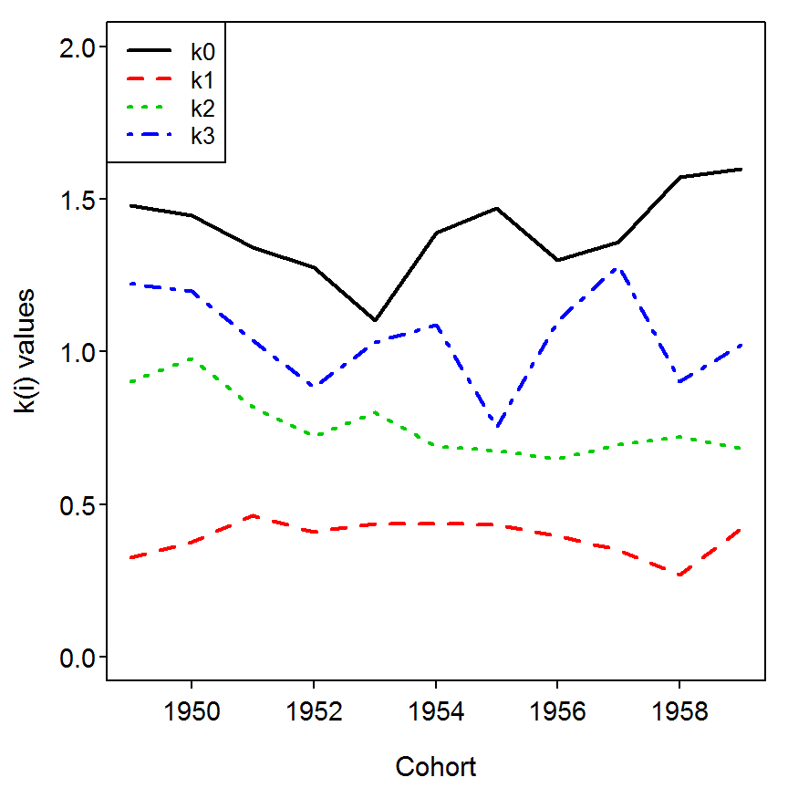

```r
> yrs <- as.numeric(rownames(kt))
> matplot(yrs,kt,type="l",lwd=2,ylim=c(0,2),xlab="Cohort",ylab="k(i) values")
> legend("topleft",c("k0","k1","k2","k3"),lty=1:4,lwd=2,col=1:4,cex=0.8)
```

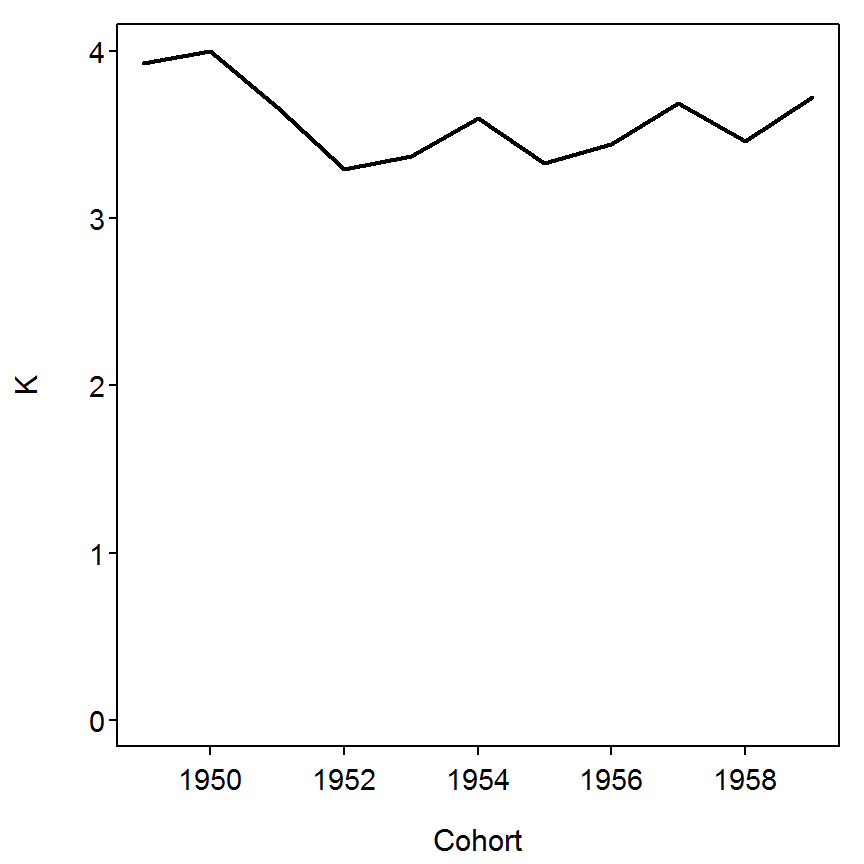

```r
> plot(K~yrs,type="l",lwd=2,ylim=c(0,max(K)),xlab="Cohort",ylab="K")
```

The author also provided a table that summarized the slope and r-square values from the regressions of a $k_{i}$ on $K$. These results, for $k_{0}$, are obtained with `lm()` and by submitting the saved `lm` object to `summary()`.

```r
> lm1 <- lm(kt[,1]~K)
> summary(lm1)
```

```
Call:
lm(formula = kt[, 1] ~ K)

Residuals:
     Min       1Q   Median       3Q      Max
-0.23696 -0.05765 -0.04188  0.07034  0.21062

Coefficients:
            Estimate Std. Error t value Pr(>|t|)
(Intercept)   0.4853     0.6548   0.741    0.478
K             0.2532     0.1819   1.392    0.197

Residual standard error: 0.1357 on 9 degrees of freedom
Multiple R-squared:  0.1772,    Adjusted R-squared:  0.08573
F-statistic: 1.938 on 1 and 9 DF,  p-value: 0.1974
```

The following loop is used to compute all four of these regressions, extract the desired results, and provide a summary table.

```r
> slps <- slpp <- rsqs <- numeric(4)             # initialize vector to hold results
> for (i in 1:4) {                               # look through k values
    lm1 <- lm(kt[,i]~K)                          # fit regression
    slps[i] <- coef(lm1)[2]                      # extract slope
    slpp[i] <- anova(lm1)[1,"Pr(>F)"]            # extract slope p-value
    rsqs[i] <- cor(kt[,i],K)^2                   # extract r-squared
  }
> round(cbind(slps,slpp,rsqs),4)                 # summary table
```

```
        slps   slpp   rsqs
[1,]  0.2532 0.1974 0.1772
[2,] -0.0618 0.4551 0.0634
[3,]  0.3051 0.0195 0.4722
[4,]  0.5034 0.0074 0.5678
```

### 13.5.6 Regression Analysis to Demonstrate Density Dependence

The author also demonstrated a method for determining if there was density dependent mortality demonstrated within any transition between age-classes. This analysis is simplified by first omitting the age column from the data frame of abundance values. Vector of adjacent ages then needs to be extracted from this matrix. The code below extracts the common logarithm of the age-1 data and places it into a vector called `Ntp1` and then extracts the same for age-0 data and places it into a vector called `Ntp`.

```r
> ( d5b <- d5a[,-1]  )                             # delete age column for simplicity
```

```
  abund.1949 abund.1950 abund.1951 abund.1952 abund.1953 abund.1954 abund.1955
1      59500      60000      55500      51000      40000      52000      73000
2       1970       2144       2516       2694       3162       2118       2474
3        933        901        865       1052       1160        779        911
4        117         95        131        199        183        159        193
5          7          6         12         26         17         13         34
  abund.1956 abund.1957 abund.1958 abund.1959
1      67000      58500      75500     100500
2       3352       2548       2019       2528
3       1348       1144       1088        968
4        302        230        208        200
5         24         12         26         19
```

```r
> ( Ntp1 <- log10(as.numeric(d5b[2,])) )
```

```
 [1] 3.294466 3.331225 3.400711 3.430398 3.499962 3.325926 3.393400 3.525304
 [9] 3.406199 3.305136 3.402777
```

```r
> ( Ntp <- log10(as.numeric(d5b[1,])) )
```

```
 [1] 4.774517 4.778151 4.744293 4.707570 4.602060 4.716003 4.863323 4.826075
 [9] 4.767156 4.877947 5.002166
```

Now the regression of the “earlier age” on the “latter age” is fit with `lm()` and the coefficients extracted with `coef()`. As the author of the box describes, the hypothesis test of interest is whether the slope from this regression is different from one or not. The `hoCoef()` function (from the `FSA` package) is designed to assist with performing non-default hypothesis tests with regression coefficients. This function requires the fitted model object as the first argument, an integer indicating which coefficient is being tests (i.e., slope=2), and the specific value in the null hypothesis (i.e., testing against a value of 1). The result indicates that the slope is significant different (i.e., lower) than 1 ($p=0.0180$).

```r
> res1 <- lm(Ntp~Ntp1)
> coef(res1)
```

```
(Intercept)        Ntp1
    5.83896    -0.31004
```

```r
> hoCoef(res1,2,1)
```

```
 term Ho Value Estimate Std. Error         T    p value
    2        1 -0.31004  0.4536832 -2.887566 0.01795532
```

A similar test for the regression in the other direction is performed with,

```r
> res2 <- lm(Ntp1~Ntp)
> coef(res2)
```

```
(Intercept)         Ntp
  4.1540141  -0.1591107
```

```r
> hoCoef(res2,2,1)
```

```
 term Ho Value   Estimate Std. Error         T      p value
    2        1 -0.1591107  0.2328275 -4.978409 0.0007610939
```

Finally, similar results for all ages can be obtained through the following loop,

```r
> slps1 <- slpp1 <- t1 <- numeric(4)      # initial vectors for 1st regression results
> slps2 <- slpp2 <- t2 <- numeric(4)      # initial vectors for 2nd regression results
> for (i in 1:4) {                        # loop through ages
    tmp2 <- log10(as.numeric(d5b[i+1,]))
    tmp1 <- log10(as.numeric(d5b[i,]))
    lm1 <- lm(tmp2~tmp1)                  # first regression
    slps1[i] <- coef(lm1)[2]              # extract results
    temp <- hoCoef(lm1,2,1)
    slpp1[i] <- temp[1,"p value"]
    t1[i] <- temp[1,"T"]
    lm2 <- lm(tmp1~tmp2)                  # second regression
    slps2[i] <- coef(lm2)[2]              # extract results
    temp <- hoCoef(lm2,2,1)
    slpp2[i] <- temp[1,"p value"]
    t2[i] <- temp[1,"T"]
  }
> round(cbind(slps1,t1,slpp1,slps2,t2,slpp2),4)  # summary table
```

```
       slps1      t1  slpp1   slps2      t2  slpp2
[1,] -0.1591 -4.9784 0.0008 -0.3100 -2.8876 0.0180
[2,]  0.6175 -1.7161 0.1203  0.7454 -0.9462 0.3688
[3,]  1.4994  1.0348 0.3278  0.3451 -5.8955 0.0002
[4,]  1.3223  0.9142 0.3844  0.4612 -4.3818 0.0018
```

### 13.5.7 Elliott (1994) Method

At the very end of the box, the author illustrates a method due to Elliott (1994) for demonstrating if density dependent mortality exists among age classes. These results are demonstrated for age-0 fish below.

```r
> tmpN <- as.numeric(d5b[1,])                    # isolate abundance data for age-0
> tmpK <- as.numeric(k[1,])                      # isolate k data for age-0
> lm1 <- lm(tmpK~tmpN)                           # regression fitting
> summary(lm1)                                   # extract results
```

```
Call:
lm(formula = tmpK ~ tmpN)

Residuals:
      Min        1Q    Median        3Q       Max
-0.127123 -0.048953  0.002496  0.073807  0.110096

Coefficients:
             Estimate Std. Error t value Pr(>|t|)
(Intercept) 9.405e-01  1.106e-01   8.503 1.36e-05
tmpN        7.217e-06  1.707e-06   4.227  0.00222

Residual standard error: 0.08656 on 9 degrees of freedom
Multiple R-squared:  0.665, Adjusted R-squared:  0.6278
F-statistic: 17.87 on 1 and 9 DF,  p-value: 0.002217
```

A plot showing the model fit can be obtained with `fitPlot()`, from the `FSA` package.

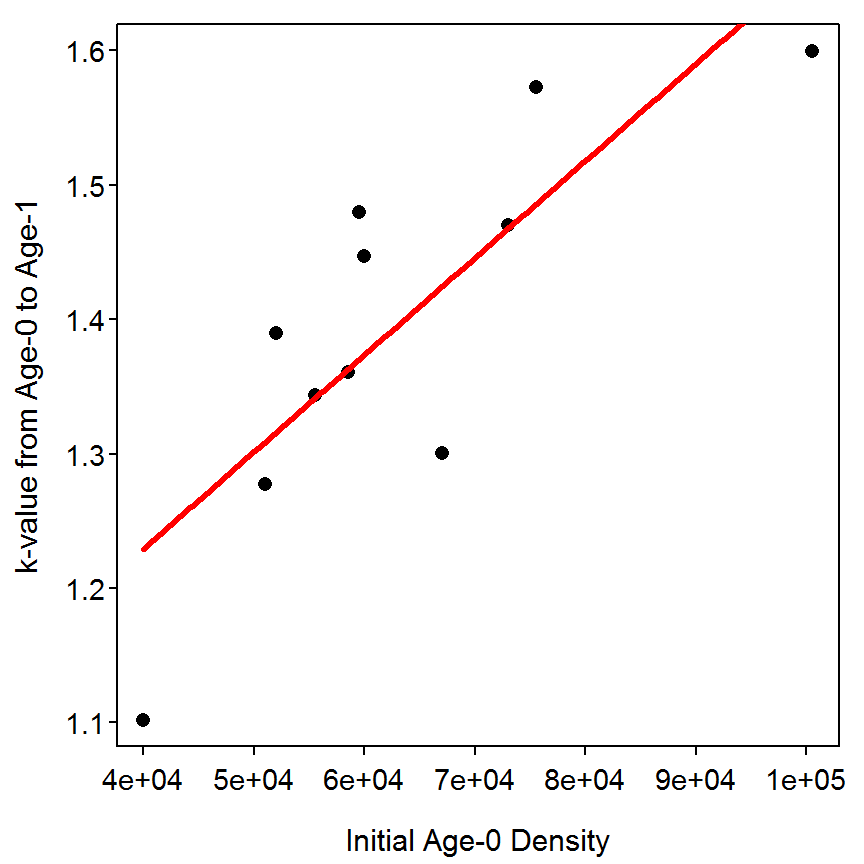

```r
> fitPlot(lm1,xlab="Initial Age-0 Density",ylab="k-value from Age-0 to Age-1",main="")
```

Similar results for all age-classes can be obtained with the following loop.

```r
> slpsE <- slppE <- tE <- numeric(4)             # initialize results vectors
> for (i in 1:4) {                               # loop through ages
    tmpN <- as.numeric(d5b[i,])
    tmpK <- as.numeric(k[i,])
    lm1 <- lm(tmpK~tmpN)                         # fit regression
    slpsE[i] <- coef(lm1)[2]                     # extract results
    temp <- hoCoef(lm1,2)
    slppE[i] <- temp[1,"p value"]
    tE[i] <- temp[1,"T"]
  }
> round(cbind(slpsE,tE,slppE),5)                 # summary table
```

```
        slpsE       tE   slppE
[1,]  0.00001  4.22680 0.00222
[2,]  0.00006  1.54454 0.15686
[3,] -0.00022 -1.11647 0.29314
[4,] -0.00054 -0.60029 0.56312
```

[output not shown]

References

Elliott, J. M. 1994. Quantitative ecology and the brown trout. Oxford University Press, Oxford, UK.

McFadden, J. T., G. R. Alexander, and D. S. Shetter. 1967. Numerical changes and population regulation in brook trout *Salvelinus fontinalis*. Journal of the Fisheries Research Board of Canada 24:1425–1459.